# Data

```python
from fiona import listlayers

russiaMapsLink="https://github.com/tatiana4321/TareaExtra/raw/main/RusiaMaps_3576.gpkg"
#layers in maps
listlayers(russiaMapsLink)
```

```
['country', 'cities', 'rivers', 'airports']
```

Let's read in the data:

```python
import geopandas as gpd

country=gpd.read_file(russiaMapsLink,layer='country')
cities=gpd.read_file(russiaMapsLink,layer='cities')
rivers=gpd.read_file(russiaMapsLink,layer='rivers')
airports=gpd.read_file(russiaMapsLink,layer='airports')
```

Adding seaports data. Let's read the UpdatedPub150.csv from the GitHub repo:

```python
import pandas as pd

portsFileLink="https://github.com/tatiana4321/TareaExtra/raw/main/UpdatedPub150.csv"
infoseaports=pd.read_csv(portsFileLink)

#columns available (so many)
infoseaports.columns.to_list()
```

```
['OID_',
 'World Port Index Number',
 'Region Name',
 'Main Port Name',
 'Alternate Port Name',
 'UN/LOCODE',
 'Country Code',
 'World Water Body',
 'IHO S-130 Sea Area',
 'Sailing Direction or Publication',
 'Publication Link',
 'Standard Nautical Chart',
 'IHO S-57 Electronic Navigational Chart',
 'IHO S-101 Electronic Navigational Chart',
 'Digital Nautical Chart',
 'Tidal Range (m)',
 'Entrance Width (m)',
 'Channel Depth (m)',
 'Anchorage Depth (m)',
 'Cargo Pier Depth (m)',
 'Oil Terminal Depth (m)',
 'Liquified Natural Gas Terminal Depth (m)',
 'Maximum Vessel Length (m)',
 'Maximum Vessel Beam (m)',
 'Maximum Vessel Draft (m)',
 'Offshore Maximum Vessel Length (m)',
 'Offshore Maximum Vessel Beam (m)',
 'Offshore Maximum Vessel Draft (m)',
 'Harbor Size',
 'Harbor Type',
 'Harbor Use',
 'Shelter Afforded',
 'Entrance Restriction - Tide',
 'Entrance Restriction - Heavy Swell',
 'Entrance Restriction - Ice',
 'Entrance Restriction - Other',
 'Overhead Limits',
 'Underkeel Clearance Management System',
 'Good Holding Ground',
 'Turning Area',
```

[output cut: 54 more lines]

```
 'Services - Electrical Repair',
 'Services - Ice Breaking',
 'Services -Diving',
 'Supplies - Provisions',
 'Supplies - Potable Water',
 'Supplies - Fuel Oil',
 'Supplies - Diesel Oil',
 'Supplies - Aviation Fuel',
 'Supplies - Deck',
 'Supplies - Engine',
 'Repairs',
 'Dry Dock',
 'Railway',
 'Latitude',
 'Longitude']
```

Doing some preprocessing:

```python
#rename
infoseaports.rename(columns={'Main Port Name':'portName', 'Country Code':'countryCode'},inplace=True)

#keep few columns
infoseaports=infoseaports.loc[:,['portName', 'countryCode','Latitude', 'Longitude']]

# we have now
infoseaports.info()
```

```
<class 'pandas.core.frame.DataFrame'>
RangeIndex: 3801 entries, 0 to 3800
Data columns (total 4 columns):
 #   Column       Non-Null Count  Dtype
---  ------       --------------  -----
 0   portName     3801 non-null   object
 1   countryCode  3801 non-null   object
 2   Latitude     3801 non-null   float64
 3   Longitude    3801 non-null   float64
dtypes: float64(2), object(2)
memory usage: 118.9+ KB
```

```python
infoseaports.head()
```

|  | portName | countryCode | Latitude | Longitude |
| --- | --- | --- | --- | --- |
| 0 | Maurer | United States | 40.533333 | -74.250000 |
| 1 | Iharana | Madagascar | -13.350000 | 50.000000 |
| 2 | Andoany | Madagascar | -13.400000 | 48.300000 |
| 3 | Chake Chake | Tanzania | -5.250000 | 39.766667 |
| 4 | Mjimwema Terminal | Tanzania | -6.816667 | 39.366667 |

Turning the points into projected spatial object (GDF of points)

```python
#spatial points (unprojected)
seaports=gpd.GeoDataFrame(data=infoseaports.copy(),
                           geometry=gpd.points_from_xy(infoseaports.Longitude,
                                                       infoseaports.Latitude),
                          crs=4326)

# keep Russia
seaports_ru=seaports[seaports['countryCode']=='Russia'].copy()

# reset indexes
seaports_ru.reset_index(drop=True, inplace=True)

# reprojecting
seaports_ru_3576=seaports_ru.to_crs(3576) # projected crs
```

```python
seaports_ru_3576.info()
```

```
<class 'geopandas.geodataframe.GeoDataFrame'>
RangeIndex: 67 entries, 0 to 66
Data columns (total 5 columns):
 #   Column       Non-Null Count  Dtype
---  ------       --------------  -----
 0   portName     67 non-null     object
 1   countryCode  67 non-null     object
 2   Latitude     67 non-null     float64
 3   Longitude    67 non-null     float64
 4   geometry     67 non-null     geometry
dtypes: float64(2), geometry(1), object(2)
memory usage: 2.7+ KB
```

Plotting seaports along with the large airports:

```python
airports.info()
```

```
<class 'geopandas.geodataframe.GeoDataFrame'>
RangeIndex: 1651 entries, 0 to 1650
Data columns (total 8 columns):
 #   Column         Non-Null Count  Dtype
---  ------         --------------  -----
 0   name           1651 non-null   object
 1   kind           1651 non-null   object
 2   latitude_deg   1651 non-null   float64
 3   longitude_deg  1651 non-null   float64
 4   elevation_ft   1034 non-null   float64
 5   region_name    1651 non-null   object
 6   municipality   1536 non-null   object
 7   geometry       1651 non-null   geometry
dtypes: float64(3), geometry(1), object(4)
memory usage: 103.3+ KB
```

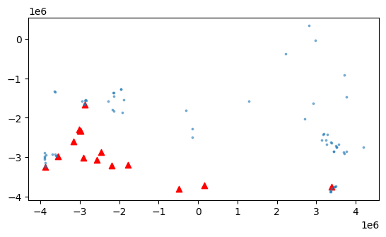

```python
# subsetting
largeAirports=airports[airports['kind']=='large_airport'] #can't use "airports.type"
largeAirports.reset_index(drop=True, inplace=True)

#plotting
base=largeAirports.plot(color='red',marker="^")
seaports_ru_3576.plot(ax=base,alpha=0.5,markersize=3)
```

# Exercise 1 (Distance between two points)

1. Use two maps of points from your country.
2. Compute the distance matrix for both maps.
3. Select one row of the distance matrix, and plot the two points with the minimal distance on top of the country of your choosing.

```python
seaports_ru_3576.head()
```

|  | portName | countryCode | Latitude | Longitude | geometry |
| --- | --- | --- | --- | --- | --- |
| 0 | Bukhta Vanino | Russia | 49.083333 | 140.283333 | POINT (3435999.476 -2854310.567) |
| 1 | Sovetskaya Gavan | Russia | 48.973611 | 140.268056 | POINT (3444029.436 -2862533.492) |
| 2 | Lazarev | Russia | 52.216667 | 141.516667 | POINT (3239715.833 -2575447.993) |
| 3 | De Kastri | Russia | 51.466667 | 140.783333 | POINT (3267591.924 -2666566.103) |
| 4 | Novorossiysk | Russia | 44.716667 | 37.783333 | POINT (-3887184.998 -3013399.055) |

```python
largeAirports.head()
```

|  | name | kind | latitude_deg | longitude_deg | elevation_ft | region_name | municipality | geometry |
| --- | --- | --- | --- | --- | --- | --- | --- | --- |
| 0 | Domodedovo International Airport | large_airport | 55.408798 | 37.906300 | 588.0 | Moscow Oblast | Moscow | POINT (-2999019.609 -2335202.716) |
| 1 | Pulkovo Airport | large_airport | 59.800301 | 30.262501 | 78.0 | Saint Petersburg (city) | St. Petersburg | POINT (-2877333.690 -1678852.818) |
| 2 | Vnukovo International Airport | large_airport | 55.591499 | 37.261501 | 685.0 | Moscow (city) | Moscow | POINT (-3009648.144 -2289543.230) |
| 3 | Sochi International Airport | large_airport | 43.449902 | 39.956600 | 89.0 | Krasnodar Krai | Sochi | POINT (-3869472.854 -3241881.698) |
| 4 | Novosibirsk Tolmachevo Airport | large_airport | 55.019756 | 82.618675 | 365.0 | Novosibirsk Oblast | Novosibirsk | POINT (-493628.256 -3810450.645) |

Let's compute all possible distances between those GDFs

```python
seaports_ru_3576.set_index('portName').geometry.apply\
(lambda g: largeAirports.set_index('name').geometry.distance(g)/1000)
```

| name portName | Domodedovo International Airport | Pulkovo Airport | Vnukovo International Airport | Sochi International Airport | Novosibirsk Tolmachevo Airport | Koltsovo Airport | Vladivostok International Airport | Kazan International Airport | Kurumoch International Airport | Krasnoyarsk International Airport | Ufa International Airport | Platov International Airport | Zhukovsky International Airport | Gagarin International Airport | Lipetsk Air Base |
| --- | --- | --- | --- | --- | --- | --- | --- | --- | --- | --- | --- | --- | --- | --- | --- |
| Bukhta Vanino | 6455.923139 | 6421.828133 | 6470.342756 | 7315.745850 | 4044.277187 | 5231.893274 | 893.546090 | 5901.985698 | 6004.142637 | 3385.757903 | 5631.047430 | 6989.282865 | 6433.692148 | 6341.043796 | 6602.843324 |
| Sovetskaya Gavan | 6464.592697 | 6431.230963 | 6479.064141 | 7323.333995 | 4050.147532 | 5239.379710 | 885.776665 | 5910.006760 | 6011.872834 | 3391.445083 | 5638.531182 | 6997.177292 | 6442.360008 | 6348.856523 | 6611.187018 |
| Lazarev | 6243.359489 | 6182.408736 | 6255.900546 | 7140.356971 | 3932.313523 | 5062.499630 | 1181.032157 | 5713.025342 | 5825.195988 | 3282.519454 | 5461.116639 | 6803.606818 | 6221.209775 | 6158.842006 | 6401.769327 |
| De Kastri | 6275.366268 | 6223.800152 | 6288.552227 | 7160.215197 | 3931.316458 | 5079.901028 | 1087.208968 | 5736.994955 | 5845.919130 | 3278.375646 | 5478.823890 | 6826.742054 | 6253.184393 | 6180.707209 | 6429.922219 |
| Novorossiysk | 1117.491849 | 1673.563062 | 1137.557993 | 229.168144 | 3485.902838 | 2110.069928 | 7315.190470 | 1428.954804 | 1324.422671 | 4109.468810 | 1716.741863 | 337.360812 | 1133.153596 | 984.466118 | 834.018877 |
| ... | ... | ... | ... | ... | ... | ... | ... | ... | ... | ... | ... | ... | ... | ... | ... |
| Shakhtersk | 6527.934940 | 6481.213908 | 6541.533091 | 7402.771904 | 4150.188766 | 5320.514439 | 1013.824870 | 5983.576349 | 6089.558369 | 3493.498358 | 5719.618327 | 7072.400726 | 6505.734599 | 6425.333952 | 6679.762680 |
| Poronaysk | 6570.188807 | 6515.955069 | 6583.295370 | 7453.872155 | 4213.024654 | 5372.862279 | 1088.706966 | 6031.623836 | 6139.865456 | 3557.583389 | 5771.863576 | 7121.202580 | 6548.010288 | 6474.920112 | 6724.918144 |
| Uglegorsk | 6533.639372 | 6487.608422 | 6547.285726 | 7407.515515 | 4153.367369 | 5325.123446 | 1007.160045 | 5988.678491 | 6094.403168 | 3496.488888 | 5724.236093 | 7077.411327 | 6511.437021 | 6430.259501 | 6685.171342 |
| Nikol Skoye | 6854.754046 | 6629.536376 | 6855.928948 | 7924.734239 | 5097.537488 | 5943.880651 | 2838.634738 | 6472.501249 | 6630.893230 | 4513.309900 | 6323.663557 | 7544.540970 | 6833.854531 | 6936.939528 | 7072.637158 |
| Vladivostok | 6554.810827 | 6614.909703 | 6575.403087 | 7283.367278 | 3887.418097 | 5212.046662 | 37.245523 | 5931.316305 | 6000.015707 | 3232.652454 | 5605.082502 | 6993.177308 | 6532.597421 | 6342.170228 | 6661.481965 |

67 rows × 15 columns

```python
#Reording previous output
seaports_ru_3576.set_index('portName').geometry.apply\
(lambda g: largeAirports.set_index('name').geometry.distance(g)/1000).sort_index(axis=0).sort_index(axis=1)
```

| name portName | Domodedovo International Airport | Gagarin International Airport | Kazan International Airport | Koltsovo Airport | Krasnoyarsk International Airport | Kurumoch International Airport | Lipetsk Air Base | Novosibirsk Tolmachevo Airport | Platov International Airport | Pulkovo Airport | Sochi International Airport | Ufa International Airport | Vladivostok International Airport | Vnukovo International Airport | Zhukovsky International Airport |
| --- | --- | --- | --- | --- | --- | --- | --- | --- | --- | --- | --- | --- | --- | --- | --- |
| Adler | 1258.344216 | 993.404835 | 1455.664994 | 2087.768179 | 4061.679718 | 1318.661088 | 955.897822 | 3426.047120 | 417.653987 | 1852.315255 | 2.657755 | 1689.128387 | 7280.798954 | 1284.453852 | 1271.429977 |
| Aleksandrovsk -Sakhalinskiy | 6382.069669 | 6291.864803 | 5847.333874 | 5192.537227 | 3394.705933 | 5957.479669 | 6538.495802 | 4047.468209 | 6937.436101 | 6325.003729 | 7272.107035 | 5591.378346 | 1121.484575 | 6394.922213 | 6359.903702 |
| Anapa | 1101.248805 | 996.616391 | 1435.974609 | 2124.846341 | 4127.518039 | 1337.789731 | 823.684631 | 3506.274861 | 345.723224 | 1646.847327 | 272.108998 | 1733.051547 | 7330.287231 | 1119.786682 | 1117.473960 |
| Arkhangels'k | 992.548097 | 1413.192551 | 1081.927641 | 1408.319432 | 2977.167323 | 1310.935111 | 1276.485043 | 2576.015699 | 1812.736744 | 749.716182 | 2228.618472 | 1389.781151 | 5856.421374 | 979.587361 | 975.292782 |
| Azov | 879.103067 | 708.575173 | 1147.828378 | 1838.221406 | 3844.376794 | 1050.331906 | 578.247887 | 3227.383939 | 57.059456 | 1482.472308 | 377.786449 | 1448.371546 | 7043.472069 | 905.453725 | 892.249031 |
| ... | ... | ... | ... | ... | ... | ... | ... | ... | ... | ... | ... | ... | ... | ... | ... |
| Vladivostok | 6554.810827 | 6342.170228 | 5931.316305 | 5212.046662 | 3232.652454 | 6000.015707 | 6661.481965 | 3887.418097 | 6993.177308 | 6614.909703 | 7283.367278 | 5605.082502 | 37.245523 | 6575.403087 | 6532.597421 |
| Vostochnyy | 6645.816719 | 6439.444895 | 6026.561464 | 5309.746629 | 3335.166504 | 6097.386611 | 6755.309615 | 3991.113394 | 7090.645238 | 6698.829979 | 7383.072547 | 5703.466606 | 105.973199 | 6665.984779 | 6623.587265 |
| Vyborg | 797.577309 | 1470.679184 | 1360.701656 | 1946.199202 | 3694.095649 | 1542.628474 | 1096.756976 | 3250.484351 | 1589.410259 | 131.308072 | 1979.391876 | 1789.097673 | 6599.884378 | 755.362152 | 796.505118 |
| Yeysk | 910.205521 | 802.914983 | 1233.751564 | 1933.616785 | 3942.103058 | 1145.169329 | 622.749905 | 3327.047589 | 156.418955 | 1486.170338 | 366.643294 | 1545.676215 | 7138.089173 | 932.188016 | 925.220056 |
| Zarubino | 6552.770408 | 6331.279836 | 5923.520760 | 5200.707695 | 3213.848293 | 5989.032404 | 6655.591883 | 3866.080632 | 6981.900550 | 6621.599287 | 7268.492929 | 5592.588168 | 122.471550 | 6573.916154 | 6530.581566 |

67 rows × 15 columns

```python
# Saving it

distanceMatrixKM_sea_air= seaports_ru_3576.set_index('portName').geometry.apply\
                          (lambda g: largeAirports.set_index('name').geometry.distance(g)/1000).\
                          sort_index(axis=0).sort_index(axis=1)
```

*Select one row of the distance matrix, and plot the two points with the minimal distance on top of the country of your choosing.*

```python
anapa_distances = distanceMatrixKM_sea_air.loc['Anapa']
closest_airport = anapa_distances.idxmin()
min_distance = anapa_distances.min()
```

```python
seaports = seaports_ru_3576.set_index('portName')
airports = largeAirports.set_index('name')
ru = country[country.COUNTRY=='Russia']
```

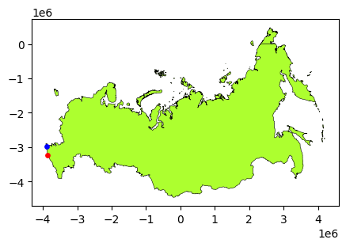

```python
base = ru.plot(facecolor="greenyellow", edgecolor='black', linewidth=0.4,figsize=(5,5))
seaports.loc[['Anapa']].plot(ax=base, color='blue', markersize=15, label='Anapa Port')
airports.loc[[closest_airport]].plot(ax=base, color='red', markersize=15, label=closest_airport)
```

# Exercise 2 (Distance between line and point)

1. Use a map of points and a map of lines from your country.
2. Compute the distance matrix for both.
3. Select one line of the distance matrix, and plot the closests and the farthest point to that line.

Let's take a look at the rivers we have:

```python
rivers.info()
```

```
<class 'geopandas.geodataframe.GeoDataFrame'>
RangeIndex: 18 entries, 0 to 17
Data columns (total 3 columns):
 #   Column    Non-Null Count  Dtype
---  ------    --------------  -----
 0   NAME      18 non-null     object
 1   SYSTEM    6 non-null      object
 2   geometry  18 non-null     geometry
dtypes: geometry(1), object(2)
memory usage: 560.0+ bytes
```

```python
distanceMatrixKM_riv_air=rivers.set_index('NAME').geometry.apply\
(lambda g: largeAirports.set_index('name').geometry.distance(g)/1000).\
sort_index(axis=0).sort_index(axis=1)
distanceMatrixKM_riv_air
```

| name NAME | Domodedovo International Airport | Gagarin International Airport | Kazan International Airport | Koltsovo Airport | Krasnoyarsk International Airport | Kurumoch International Airport | Lipetsk Air Base | Novosibirsk Tolmachevo Airport | Platov International Airport | Pulkovo Airport | Sochi International Airport | Ufa International Airport | Vladivostok International Airport | Vnukovo International Airport | Zhukovsky International Airport |
| --- | --- | --- | --- | --- | --- | --- | --- | --- | --- | --- | --- | --- | --- | --- | --- |
| Aldan | 4864.775730 | 4829.445667 | 4373.764584 | 3754.637276 | 1960.448250 | 4504.217897 | 5039.008818 | 2611.031144 | 5464.693068 | 4777.327416 | 5818.833079 | 4153.784026 | 1497.011575 | 4874.867508 | 4842.791739 |
| Amur | 5200.651184 | 5001.416491 | 4584.448877 | 3872.414295 | 1919.113849 | 4659.501073 | 5311.110565 | 2567.876647 | 5652.779562 | 5264.608868 | 5949.350677 | 4267.189628 | 451.379540 | 5220.971018 | 5178.425904 |
| Angara | 3401.368853 | 3135.261274 | 2737.058361 | 2004.488333 | 216.147267 | 2792.997677 | 3476.557687 | 754.950183 | 3785.273457 | 3573.500401 | 4073.551535 | 2395.381975 | 2062.952729 | 3427.247942 | 3379.555651 |
| Dnieper | 253.343981 | 938.860370 | 994.934387 | 1714.949394 | 3647.787448 | 1109.925142 | 473.650576 | 3123.421043 | 913.339487 | 471.919094 | 1297.539945 | 1449.816126 | 6705.479727 | 208.070535 | 266.771240 |
| Don | 141.966632 | 288.423010 | 708.561696 | 1408.059578 | 3407.227397 | 625.758201 | 23.950111 | 2787.415518 | 28.118529 | 799.007169 | 383.105009 | 1013.768215 | 6597.661299 | 176.815968 | 153.208633 |
| Irtysh | 1937.617920 | 1632.665142 | 1239.133031 | 502.254364 | 1127.669123 | 1290.439145 | 1982.567421 | 514.075959 | 2283.465177 | 2168.562561 | 2583.180502 | 897.385607 | 4351.427825 | 1968.596526 | 1916.613553 |
| Kama | 775.042339 | 443.286680 | 42.762900 | 305.898685 | 2188.383583 | 189.269343 | 751.405599 | 1669.537584 | 1078.998590 | 1291.832414 | 1433.921022 | 196.760245 | 5299.507884 | 816.207450 | 757.887304 |
| Kolyma | 5380.146095 | 5489.126032 | 5024.270223 | 4514.575545 | 3073.780419 | 5188.079610 | 5604.502182 | 3658.412326 | 6085.485151 | 5130.966913 | 6472.175702 | 4888.972927 | 2135.435295 | 5380.165447 | 5359.452598 |
| Lena | 4167.539560 | 3931.671386 | 3524.550561 | 2801.423113 | 849.219231 | 3589.477626 | 4259.194548 | 1508.652588 | 4582.582858 | 4067.617571 | 4875.266657 | 3194.729323 | 1895.414150 | 4190.853334 | 4145.481971 |
| Neva | 607.016906 | 1255.579445 | 1122.630848 | 1697.299076 | 3466.381301 | 1312.207510 | 916.915536 | 3010.580128 | 1433.780395 | 12.398150 | 1832.690601 | 1544.301761 | 6397.169568 | 569.784201 | 601.796305 |
| Ob | 1791.325175 | 1686.375672 | 1229.657099 | 667.471590 | 510.944791 | 1367.735847 | 1918.301936 | 31.149404 | 2321.048790 | 1919.804627 | 2677.012151 | 1053.577328 | 3668.967667 | 1811.681592 | 1769.090179 |
| Pechora | 1335.903340 | 1280.544352 | 815.797968 | 571.207648 | 2018.052943 | 988.848290 | 1470.602489 | 1571.881323 | 1896.140120 | 1306.470595 | 2268.221156 | 777.082102 | 5054.863938 | 1356.008838 | 1313.665043 |
| Suir | 600.495601 | 1174.037144 | 971.710891 | 1504.837230 | 3252.696847 | 1177.304288 | 909.018179 | 2804.363419 | 1444.551200 | 176.127848 | 1857.230930 | 1373.909532 | 6166.554361 | 575.163761 | 588.356011 |
| Tobol | 1756.111237 | 1296.397408 | 1005.658797 | 330.549405 | 1519.717546 | 968.536540 | 1723.154263 | 967.918362 | 1926.078822 | 2185.200030 | 2180.952648 | 564.499781 | 4703.254422 | 1795.047109 | 1737.741519 |
| Ural | 1098.314466 | 465.571104 | 489.216714 | 225.887053 | 2150.469490 | 270.298183 | 952.973483 | 1535.552791 | 1055.087481 | 1694.223446 | 1308.814936 | 237.107457 | 5362.329800 | 1144.484880 | 1086.782779 |
| Vilyuy | 3636.781868 | 3560.515634 | 3108.929661 | 2491.930020 | 1230.810948 | 3232.082428 | 3791.743023 | 1667.767794 | 4200.566591 | 3620.359234 | 4547.900094 | 2885.434639 | 2205.932291 | 3650.706875 | 3614.573364 |
| Volga | 153.893727 | 13.700517 | 0.119222 | 747.900600 | 2756.929078 | 2.781843 | 465.182178 | 2178.105045 | 398.658091 | 308.071154 | 668.043605 | 400.637403 | 5914.250659 | 119.852800 | 149.462199 |
| Yenisey | 2716.188582 | 2753.010208 | 2288.392825 | 1674.927862 | 16.309138 | 2438.096728 | 2907.111209 | 573.227369 | 3363.237146 | 2633.499707 | 3740.548502 | 2072.886048 | 2770.144082 | 2724.264638 | 2694.403865 |

```python
!pip install mapclassify
```

```
     ━━━━━━━━━━━━━━━━━━━━━━━━━━━━━━━━━━━━━━━━ 58.6/58.6 kB 963.4 kB/s eta 0:00:00
```

```python
ob_river = distanceMatrixKM_riv_air.loc['Ob']
min = ob_river.idxmin()
max = ob_river.idxmax()
```

```python
ob = rivers[rivers['NAME'] == 'Ob'].copy()
closest_airport = largeAirports[largeAirports['name'] == min].copy()
farthest_airport = largeAirports[largeAirports['name'] == max].copy()
```

```python
# Plotting the river and the closest and farthest airports
base=ob.explore(color='blue')
closest_airport.explore(m=base, color='red', marker_kwds=dict(radius=5))
farthest_airport.explore(m=base, color='green', marker_kwds=dict(radius=5))
```

Make this Notebook Trusted to load map: File -> Trust Notebook

[interactive chart not shown]

Now, let's focus on the rivers that belong to a system:

```python
rivers
```

|  | NAME | SYSTEM | geometry |
| --- | --- | --- | --- |
| 0 | Don | None | LINESTRING (-3603827.117 -2965834.980, -354442... |
| 1 | Ural | None | MULTILINESTRING ((-2564645.559 -3343971.198, -... |
| 2 | Dnieper | None | LINESTRING (-3106755.888 -2091252.001, -311286... |
| 3 | Volga | None | LINESTRING (-3024254.968 -1949633.124, -304789... |
| 4 | Amur | None | MULTILINESTRING ((2076412.934 -3891300.095, 20... |
| 5 | Irtysh | Ob | LINESTRING (-1007373.782 -3828879.610, -102079... |
| 6 | Tobol | Ob | LINESTRING (-1706906.012 -3524475.237, -170173... |
| 7 | Angara | None | MULTILINESTRING ((1084472.706 -4025265.396, 10... |
| 8 | Ob | Ob | MULTILINESTRING ((-1136717.208 -2972266.070, -... |
| 9 | Aldan | Lena | LINESTRING (2062501.612 -3057003.723, 2011720.... |
| 10 | Yenisey | None | MULTILINESTRING ((637756.065 -4050854.493, 584... |
| 11 | Kama | None | LINESTRING (-2057072.686 -2828765.853, -204765... |
| 12 | Neva | None | MULTILINESTRING ((-2828633.894 -1716872.710, -... |
| 13 | Suir | None | MULTILINESTRING ((-2614529.572 -1833514.376, -... |
| 14 | Pechora | None | LINESTRING (-1548828.072 -2645390.886, -156992... |
| 15 | Lena | Lena | MULTILINESTRING ((1865098.500 -2255215.698, 18... |
| 16 | Vilyuy | Lena | LINESTRING (1686760.007 -2268614.350, 1696838.... |
| 17 | Kolyma | None | LINESTRING (2198322.970 -754373.634, 2245534.0... |

```python
rivers[~rivers.SYSTEM.isna()]
```

|  | NAME | SYSTEM | geometry |
| --- | --- | --- | --- |
| 5 | Irtysh | Ob | LINESTRING (-1007373.782 -3828879.610, -102079... |
| 6 | Tobol | Ob | LINESTRING (-1706906.012 -3524475.237, -170173... |
| 8 | Ob | Ob | MULTILINESTRING ((-1136717.208 -2972266.070, -... |
| 9 | Aldan | Lena | LINESTRING (2062501.612 -3057003.723, 2011720.... |
| 15 | Lena | Lena | MULTILINESTRING ((1865098.500 -2255215.698, 18... |
| 16 | Vilyuy | Lena | LINESTRING (1686760.007 -2268614.350, 1696838.... |

Let's dissolve the ones that belong to a system into a multiline:

```python
systems=rivers.dissolve(by='SYSTEM')
systems
```

| SYSTEM | geometry | NAME |
| --- | --- | --- |
| Lena | MULTILINESTRING ((2062501.612 -3057003.723, 20... | Aldan |
| Ob | MULTILINESTRING ((-1007373.782 -3828879.610, -... | Irtysh |

Let's do some basic formatting:

```python
# format the GDF:

systems.reset_index(drop=False,inplace=True)
systems.drop(columns='NAME',inplace=True)

# we have
systems
```

|  | SYSTEM | geometry |
| --- | --- | --- |
| 0 | Lena | MULTILINESTRING ((2062501.612 -3057003.723, 20... |
| 1 | Ob | MULTILINESTRING ((-1007373.782 -3828879.610, -... |

Another distance matrix:

```python
distanceMatrixKM_sys_air=systems.set_index('SYSTEM').geometry.apply\
(lambda g: largeAirports.set_index('name').geometry.distance(g)/1000).\
sort_index(axis=0).sort_index(axis=1)

distanceMatrixKM_sys_air
```

| name SYSTEM | Domodedovo International Airport | Gagarin International Airport | Kazan International Airport | Koltsovo Airport | Krasnoyarsk International Airport | Kurumoch International Airport | Lipetsk Air Base | Novosibirsk Tolmachevo Airport | Platov International Airport | Pulkovo Airport | Sochi International Airport | Ufa International Airport | Vladivostok International Airport | Vnukovo International Airport | Zhukovsky International Airport |
| --- | --- | --- | --- | --- | --- | --- | --- | --- | --- | --- | --- | --- | --- | --- | --- |
| Lena | 3636.781868 | 3560.515634 | 3108.929661 | 2491.930020 | 849.219231 | 3232.082428 | 3791.743023 | 1508.652588 | 4200.566591 | 3620.359234 | 4547.900094 | 2885.434639 | 1497.011575 | 3650.706875 | 3614.573364 |
| Ob | 1756.111237 | 1296.397408 | 1005.658797 | 330.549405 | 510.944791 | 968.536540 | 1723.154263 | 31.149404 | 1926.078822 | 1919.804627 | 2180.952648 | 564.499781 | 3668.967667 | 1795.047109 | 1737.741519 |

Let's get all the minimun distances:

```python
mins=distanceMatrixKM_sys_air.idxmin(axis="columns") # same as axis=1
mins
```

```
SYSTEM
Lena    Krasnoyarsk International Airport
Ob         Novosibirsk Tolmachevo Airport
dtype: object
```

Finally:

```python
base=systems.explore()
# the closest
largeAirports[largeAirports.name.isin(mins)].explore(m=base,color='red',marker_kwds=dict(radius=10))
# NOT the closest
largeAirports[~largeAirports.name.isin(mins)].explore(m=base,color='blue',marker_kwds=dict(radius=5))
```

Make this Notebook Trusted to load map: File -> Trust Notebook

[interactive chart not shown]

# Exercise 3 (Polygon to point)

1. Create a HULL for some set of line map.
2. Compute the distance matrix between the HULLS and a map of points.
3. Plot the HULLS and the points. Show the closest and farthest points to the HULL.

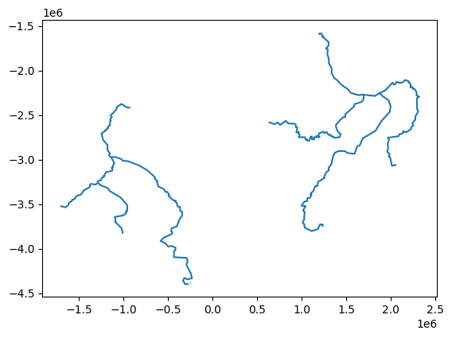

```python
systems.plot()
```

```python
# polygon for each system
systems.convex_hull
```

```
0    POLYGON ((1111476.898 -3800925.630, 1034119.83...
1    POLYGON ((-306634.030 -4396234.128, -1706906.0...
dtype: geometry
```

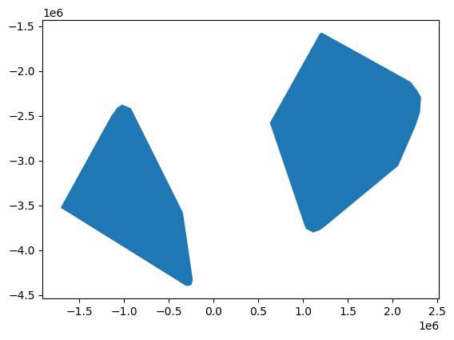

```python
# see them
systems.convex_hull.plot()
```

Now, a GDF for the hulls:

```python
systems_hulls=systems.convex_hull.to_frame()
systems_hulls['system']=['Lena', 'Ob']
systems_hulls.rename(columns={0:'geometry'},inplace=True)
systems_hulls=systems_hulls.set_geometry('geometry')
systems_hulls.crs="EPSG:3576"
systems_hulls
```

|  | geometry | system |
| --- | --- | --- |
| 0 | POLYGON ((1111476.898 -3800925.630, 1034119.83... | Lena |
| 1 | POLYGON ((-306634.030 -4396234.128, -1706906.0... | Ob |

Next, the distance matrix:

```python
distanceMatrixKM_sysHull_air=systems_hulls.set_index('system').geometry.apply\
(lambda g: largeAirports.set_index('name').geometry.distance(g)/1000).\
sort_index(axis=0).sort_index(axis=1)

distanceMatrixKM_sysHull_air
```

| name system | Domodedovo International Airport | Gagarin International Airport | Kazan International Airport | Koltsovo Airport | Krasnoyarsk International Airport | Kurumoch International Airport | Lipetsk Air Base | Novosibirsk Tolmachevo Airport | Platov International Airport | Pulkovo Airport | Sochi International Airport | Ufa International Airport | Vladivostok International Airport | Vnukovo International Airport | Zhukovsky International Airport |
| --- | --- | --- | --- | --- | --- | --- | --- | --- | --- | --- | --- | --- | --- | --- | --- |
| Lena | 3636.781868 | 3560.515634 | 3108.929661 | 2491.930020 | 808.198088 | 3232.082428 | 3791.743023 | 1459.233194 | 4200.566591 | 3620.359234 | 4547.900094 | 2885.434639 | 1497.011575 | 3650.706875 | 3614.573364 |
| Ob | 1705.857116 | 1296.397408 | 983.296215 | 227.907791 | 477.690536 | 968.536540 | 1719.937118 | 0.000000 | 1926.078822 | 1916.380431 | 2180.952648 | 563.386598 | 3668.582499 | 1737.220343 | 1684.990679 |

```python
ob_system = distanceMatrixKM_sysHull_air.loc['Ob']
min_ob = ob_system.idxmin()
max_ob = ob_system.idxmax()

lena_system = distanceMatrixKM_sysHull_air.loc['Lena']
min_lena = lena_system.idxmin()
max_lena = lena_system.idxmax()
```

```python
mins=distanceMatrixKM_sysHull_air.idxmin(axis="columns")
maxs=distanceMatrixKM_sysHull_air.idxmax(axis="columns")

mins, maxs
```

```
(system
 Lena    Krasnoyarsk International Airport
 Ob         Novosibirsk Tolmachevo Airport
 dtype: object,
 system
 Lena          Sochi International Airport
 Ob      Vladivostok International Airport
 dtype: object)
```

```python
# plotting
base=systems_hulls.explore()
largeAirports[largeAirports.name.isin(mins)].explore(m=base,color='red',marker_kwds=dict(radius=10))
largeAirports[~largeAirports.name.isin(mins + maxs)].explore(m=base,color='blue',marker_kwds=dict(radius=5))
largeAirports[largeAirports.name.isin(maxs)].explore(m=base,color='green',marker_kwds=dict(radius=10))
```

Make this Notebook Trusted to load map: File -> Trust Notebook

[interactive chart not shown]

# Exercise 4 (Distance using buffers)

1. Select a line map and a point one.
2. Get the buffer for the lines, select a distance.
3. Keep the points that are within the buffer (you might need to play with differnt distances until you show something interesting).

```python
minMts=distanceMatrixKM_riv_air.loc['Ob'].min()*1000 # km

#the buffer is a polygon:
rivers[rivers.NAME=='Ob'].buffer(distance = minMts)
```

```
8    POLYGON ((-1237545.684 -2661697.116, -1237367....
dtype: geometry
```

```python
small_airports=airports[airports['kind']=='small_airport']
small_airports.info()
```

```
<class 'geopandas.geodataframe.GeoDataFrame'>
Index: 0 entries
Data columns (total 7 columns):
 #   Column         Non-Null Count  Dtype
---  ------         --------------  -----
 0   kind           0 non-null      object
 1   latitude_deg   0 non-null      float64
 2   longitude_deg  0 non-null      float64
 3   elevation_ft   0 non-null      float64
 4   region_name    0 non-null      object
 5   municipality   0 non-null      object
 6   geometry       0 non-null      geometry
dtypes: float64(3), geometry(1), object(3)
memory usage: 108.0+ bytes
```

```python
airports.kind.value_counts()
```

```
kind
large_airport    15
Name: count, dtype: int64
```

```python
# see buffer:
bufferAroundOb=rivers[rivers.NAME=='Ob'].buffer(distance = minMts)
bufferAsBase=bufferAroundOb.explore(color='red')
rivers[rivers.NAME=='Ob'].explore(m=bufferAsBase,color='blue',style_kwds={'weight':0.5})
largeAirports.explore(m=bufferAsBase,color='black')
```

Make this Notebook Trusted to load map: File -> Trust Notebook

[interactive chart not shown]

```python
# see buffer:
bufferAroundOb=rivers[rivers.NAME=='Ob'].buffer(distance = minMts*2)
bufferAsBase=bufferAroundOb.explore(color='red', style_kwds={'weight': 3})
rivers[rivers.NAME=='Ob'].explore(m=bufferAsBase,color='blue',style_kwds={'weight':0.5})
largeAirports.explore(m=bufferAsBase,color='black')
```

Make this Notebook Trusted to load map: File -> Trust Notebook

[interactive chart not shown]

Using the buffer (polygon) to keep the airports that are at that particular distance around the river:

```python
riversWithinBuffer=largeAirports.clip(mask=bufferAroundOb)
riversWithinBuffer
```

|  | name | kind | latitude_deg | longitude_deg | elevation_ft | region_name | municipality | geometry |
| --- | --- | --- | --- | --- | --- | --- | --- | --- |
| 4 | Novosibirsk Tolmachevo Airport | large_airport | 55.019756 | 82.618675 | 365.0 | Novosibirsk Oblast | Novosibirsk | POINT (-493628.256 -3810450.645) |

```python
# plotting the airports within buffer
bufferAsBase=bufferAroundOb.explore(color='red')
rivers[rivers.NAME=='Ob'].explore(m=bufferAsBase,color='blue',style_kwds={'weight':0.5})
riversWithinBuffer.explore(m=bufferAsBase,color='black')
```

Make this Notebook Trusted to load map: File -> Trust Notebook

[interactive chart not shown]

```python
# minimum of all the minimum by row
distanceMatrixKM_riv_air.min(axis=1).min()
```

```
0.11922216278431494
```

```python
# using the previous value
minMinMts_5=5*distanceMatrixKM_riv_air.min(axis=1).min()*1000


allMinBuffer=rivers.buffer(distance = minMinMts_5).explore(color='red')
rivers.explore(m=allMinBuffer,color='blue',style_kwds={'weight':0.5})
```

Make this Notebook Trusted to load map: File -> Trust Notebook

[interactive chart not shown]

```python
# you see all the buffer polygons:
riversAll_buf=rivers.buffer(distance = minMinMts_5*5)
riversAll_buf
```

```
0     POLYGON ((-3542973.829 -3013693.064, -3475250....
1     MULTIPOLYGON (((-2190908.470 -3621985.914, -21...
2     POLYGON ((-3110052.330 -2109857.201, -3110163....
3     POLYGON ((-3044517.077 -1973217.337, -3026207....
4     MULTIPOLYGON (((3164815.855 -3250167.561, 3164...
5     POLYGON ((-1023518.900 -3771245.745, -1095378....
6     POLYGON ((-1703434.309 -3518432.169, -1703198....
7     POLYGON ((949473.752 -3936136.392, 949225.573 ...
8     MULTIPOLYGON (((-1164869.849 -2953751.917, -11...
9     POLYGON ((2012310.652 -3070188.496, 2012022.41...
10    MULTIPOLYGON (((-267599.232 -2199531.050, -267...
11    POLYGON ((-2051061.557 -2806614.209, -2059021....
12    POLYGON ((-2850624.336 -1715292.535, -2850910....
13    POLYGON ((-2648674.583 -1790050.458, -2648393....
14    POLYGON ((-1568339.469 -2661197.554, -1568597....
15    MULTIPOLYGON (((1210605.047 -1573682.397, 1210...
16    POLYGON ((1699451.544 -2285542.711, 1699573.25...
17    POLYGON ((2246685.866 -771405.725, 2246955.700...
dtype: geometry
```

Now keep large airports in buffer:

```python
allRiversWithinBuffs=largeAirports.clip(riversAll_buf)
allRiversWithinBuffs
```

|  | name | kind | latitude_deg | longitude_deg | elevation_ft | region_name | municipality | geometry |
| --- | --- | --- | --- | --- | --- | --- | --- | --- |
| 8 | Kurumoch International Airport | large_airport | 53.504902 | 50.164299 | 477.0 | Samara Oblast | Samara | POINT (-2564134.582 -3073673.498) |
| 7 | Kazan International Airport | large_airport | 55.606201 | 49.278702 | 411.0 | Republic of Tatarstan | Kazan | POINT (-2465976.887 -2864807.879) |

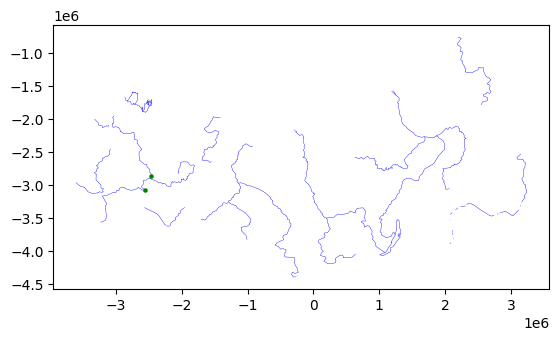

```python
# simple
base=riversAll_buf.plot(color='blue')
allRiversWithinBuffs.plot(ax=base, color='green', markersize=5)
```

```python
# folium

base=riversAll_buf.explore(color='yellow')
allRiversWithinBuffs.explore(m=base, color='green')
```

Make this Notebook Trusted to load map: File -> Trust Notebook

[interactive chart not shown]

❤